# Text_BSC

Ich habe vor kurzem ein Buch gelesen, in dem die Stimmung im Verlaufe des Buches nach unten ging. Jetzt habe ich mich gefragt: Kann man das irgendwie automatisiert nachvollziehen?

Als Ansatz habe ich mir folgendes überlegt: Word2Vec-Modelle geben mir die Möglichkeit, Worte in einen n-dimensionalen Raum zu mappen, sodass Worte, die häufig im selben Kontext (bezogen auf den Korpus, auf dem trainiert wird) erscheinen, nah aneinander sind. Synonyme haben also geringe Distanz, "Buch" und "lesen" haben geringe Distanz voneinander etc.

Google stellt ein solches vortrainiertes Modell bereit, dass auf Google-News-Artikeln trainiert wurde und auf 300 Dimensionen mappt. Ich werde dieses benutzen und dann mal schauen, was sich ergibt.

Das Buch habe ich als HTML-Datei lokal auf dem Rechner.

```python
file = open('Best_Served_Cold.html', "r")
text=file.read().lower()
```

```python
text[:1000]
```

```
'\nthe sunrise was the colour of bad blood. it leaked out of the east and stained the dark sky red, marked the scraps of cloud with stolen gold. underneath it the road twisted up the mountainside towards the fortress of fontezarmo—a cluster of sharp towers, ash-black against the wounded heavens. the…
```

```python
import pandas as pd
import re
import matplotlib.pyplot as plt
import numpy as np

from IPython.display import display, HTML


pd.options.display.max_colwidth = 500 # Damit man beim Anzeigen von Text in DataFrames den ganzen Satz lesen kann
```

Zuerst muss ich mich um die html-Tags kümmern. Dazu lasse ich mir alle anzeigen und entscheide dann, ob ich die nicht einfach alle entfernen kann.

```python
listOfTags = list()
textToSearch = text
while True:
    positionStart = textToSearch.find("<")
    positionEnd = textToSearch.find(">") + 1
    listOfTags.append(textToSearch[positionStart:positionEnd])
    textToSearch = textToSearch[positionEnd:]
    if positionStart == -1:  # no more Tags
        break

pd.Series(listOfTags).value_counts()[:10]
```

```
</font>                                   619
<font size="+2">                          619
</a>                                      138
<p align="center">                        108
</p>                                      108
<strong>                                   69
</strong>                                  69
<a name="bestservedcold_part-2.html">       1
<a name="bestservedcold_chap-25.html">      1
<a name="bestservedcold_chap-30.html">      1
dtype: int64
```

Das kann alles weg.

```python
#delete Tags
text2=text
while True:
    positionStart=text2.find("<")
    positionEnd=text2.find(">") +1
    if positionStart==-1 or positionEnd==-1 : #no more Tags
      break
    text2=text2[:positionStart] +  text2[positionEnd:]


#replace line breaks/nbsp
text3=text2 \
    .replace("\n"," ") \
    .replace("&nbsp;"," ") \
    .replace("&nbsp"," ") \

#multiple whitespaces to 1
text3=re.sub("\s+"," ",text3)
text3[:1000]
```

```
' the sunrise was the colour of bad blood. it leaked out of the east and stained the dark sky red, marked the scraps of cloud with stolen gold. underneath it the road twisted up the mountainside towards the fortress of fontezarmo—a cluster of sharp towers, ash-black against the wounded heavens. the …
```

Als nächstes kümmere ich mich um das Trennen von Sätzen. Dafür ist für mich interessant, ob ich Punkte nehmen kann oder ob häufig ein Begriff abgekürzt wird.

```python
#a word before .
pattern="[A-z]+\."
matches = re.findall(pattern,text3)
pd.Series(matches).value_counts()[:20]
```

```
it.       425
him.      272
her.      223
you.      161
face.     157
them.     142
that.     122
me.       116
back.     112
hand.     112
one.      103
now.       98
out.       89
head.      86
again.     85
up.        82
away.      79
way.       76
monza.     69
man.       69
dtype: int64
```

Nein, sieht nicht so aus. Ich ersetze jetzt noch ein paar Dinge (andere Satzzeichen zu Punkten, Abkürzungen zum vollen Äquivalent) und entferne Sonderzeichen.

Dann kann ich den Text als Liste von Sätzen darstellen, die jeweils Listen von Wörtern sind.

```python
text4=text3 \
        .replace("?",".")\
        .replace("!",".")\
        .replace("’","'") \
        .replace("ain't","is not") \
        .replace("can't","cannot") \
        .replace("'ll"," will") \
        .replace("n't"," not")  \
        .replace("'m"," am")    \
        .replace("'d", " would") \
        .replace("'ve", " have") \
        .replace("'re", " are")  \
        .replace("'em", " them")
```

```python
marks=[",",";","(",")",'"','”','“',"",":","...","…","'s","'"]
for mark in marks:
    text4=text4.replace(mark,"")
text4=text4.replace("-"," ")
```

```python
text5=text4.split(".")
text6=[[word for word in sentence.split(' ') if len(word)>0] for sentence in text5]
text6[:2]
```

```
[['the', 'sunrise', 'was', 'the', 'colour', 'of', 'bad', 'blood'],
 ['it',
  'leaked',
  'out',
  'of',
  'the',
  'east',
  'and',
  'stained',
  'the',
  'dark',
  'sky',
  'red',
  'marked',
  'the',
  'scraps',
  'of',
  'cloud',
  'with',
  'stolen',
  'gold']]
```

Als nächstes werde ich die Worte bezüglich ihrer Ähnlichkeit zu *evil* scoren. Dafür habe ich mir ein pre-trainend word2vec-Model, das von Google bereit gestellt wird, heruntergeladen.

```python
import gensim

path=r'''GoogleNews-vectors-negative300.bin'''
model = gensim.models.KeyedVectors.load_word2vec_format(path, binary=True)
```

```python
wordToCompare="evil"

l2=list()
listWordsNotFound=list()
for sentence in text6:
    sentenceList=list()
    for word in sentence:
        try:
            sim=model.similarity(word,wordToCompare)
            sentenceList.append((word,sim))
        except:
           listWordsNotFound.append(word)
    l2.append(sentenceList)
```

```python
l2[:20]
```

```
[[('the', 0.03428752143807745),
  ('sunrise', 0.12993731825213012),
  ('was', 0.04421085608541252),
  ('the', 0.03428752143807745),
  ('bad', 0.32936900056669693),
  ('blood', 0.12660165747537339)],
 [('it', 0.11010702752673779),
  ('leaked', 0.010125699779422834),
  ('out', 0.08701840907543076),
  ('the', 0.03428752143807745),
  ('east', 0.09384048059862404),
  ('stained', 0.06522448845239351),
  ('the', 0.03428752143807745),
  ('dark', 0.2964391124652071),
  ('sky', 0.17019939369613296),
  ('red', 0.09676701532683536),
  ('marked', -0.036419515692724815),
  ('the', 0.03428752143807745),
  ('scraps', 0.051043251996713127),
  ('cloud', 0.06343056048324336),
  ('with', 0.01969356427235566),
  ('stolen', 0.03916418023871722),
  ('gold', 0.0753016660259007)],
 [('underneath', 0.06435944923584946),
  ('it', 0.11010702752673779),
  ('the', 0.03428752143807745),
  ('road', 0.05024033560533357),
  ('twisted', 0.32166980273477264),
  ('up', -0.02663672282903328),
  ('the', 0.03428752143807745),
  ('mountainside', 0.09851238756567735),
  ('towards', 0.01567886767206099),
  ('the', 0.03428752143807745),
  ('fortress', 0.19117697505394998),
  ('cluster', 0.008514084478073187),
  ('sharp', 0.05521411485639756),
  ('towers', 0.11974082158759707),
  ('ash', 0.013094292452147566),
  ('black', 0.185261938440267),
  ('against', 0.11637186495717468),
```

[output cut: 99 more lines]

```
  ('yesterday', 0.005399763139012263)],
 [('curtain', 0.10328175937620815), ('midnight', 0.11557340858825482)],
 [('i', 0.11227407647361543),
  ('liked', 0.1192930766016345),
  ('that', 0.1799255258105551),
  ('better', 0.06188617296784302),
  ('it', 0.11010702752673779),
  ('had', 0.06125909578973436),
  ('some', 0.036439663449791354),
  ('poetry', 0.09523482396697122),
  ('it', 0.11010702752673779)],
 [('bad', 0.32936900056669693),
  ('poetry', 0.09523482396697122),
  ('but', 0.09355099075292295),
  ('still', 0.056000358113019205)]]
```

```python
pd.Series(listWordsNotFound).value_counts()[:30]
```

```
a            6067
of           5586
and          5372
to           4580
monza         712
cosca         603
morveer       358
orso          357
rogont        213
murcatto      202
benna         187
vitari        168
styria        152
talins        131
ganmark       125
shenkt        121
ario          108
salier         93
foscar         89
victus         87
axe            79
visserine      70
sipani         70
andiche        68
sajaam         66
gobba          63
armour         61
gurkish        60
sesaria        60
northman       58
dtype: int64
```

Hauptsächlich Eigennamen. Mir nicht ganz klar, warum er Axt nicht kennt. Das mit Armour und grey ist schade, wahrscheinlich kennt er dann auch colour, neighbour etc. nicht. Das wäre mir jetzt aber zu viel Aufwand, das zu ersetzen.

Es fällt mir auch auf, dass *Shivers* fehlt. Das ist hier ein Eigenname, wird aber wahrscheinlich wirklich als Zittern erkannt. Man könnte vor dem toLower() das noch ersetzen, aber ich denke, das wird auch so passen.

Jetzt habe ich jedes Wort auf die Ähnlichkeit seines (durchschnittlichen) Kontextes zum Kontext von *evil* gemappt. Jetzt ist noch die Frage, wie ich das am besten aggregiere. Mit "einfach pro Satz mitteln" scheint man wohl gute Erfahrungen gemacht zu haben.

|  | text | value |
| --- | --- | --- |
| 13147 | fucking evil bitch | 0.558137 |
| 5161 | god | 0.498507 |
| 5151 | god | 0.498507 |
| 5035 | you evil bitches | 0.482947 |
| 2249 | bastard | 0.419181 |
| 2250 | bastard | 0.419181 |
| 8053 | vengeance | 0.415824 |
| 7181 | vengeance | 0.415824 |
| 7184 | vengeance | 0.415824 |
| 73 | coward | 0.400973 |
| 7512 | bastards | 0.382103 |
| 6273 | bastards | 0.382103 |
| 17276 | innocent | 0.379174 |
| 13611 | traitor | 0.377377 |
| 6271 | murderers | 0.373046 |
| 13590 | stupid | 0.367899 |
| 5546 | poisoners | 0.367149 |
| 2840 | sorcery | 0.366828 |
| 2835 | sorcery | 0.366828 |
| 7997 | assassins | 0.364987 |

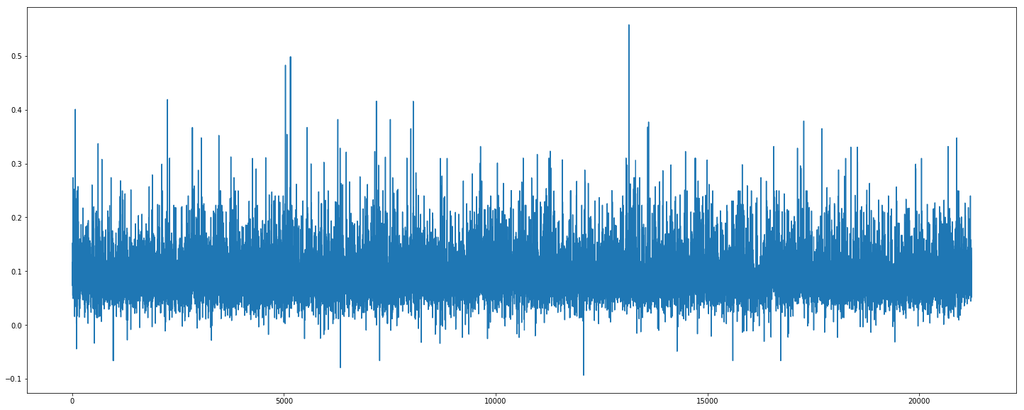

```python
def score(list_sentence, func_aggregate_sentences):
    list_sentence_scored=[func_aggregate_sentences(sentence) for sentence in list_sentence]

    #Verlauf der Scores anzeigen
    plt.figure(figsize=(25,10))
    values=[tupel[1] for tupel in list_sentence_scored]
    plt.plot(values)

    #Top 20 Sätze bezüglich aggregierter Similarity anzeigen
    display(pd.DataFrame(list_sentence_scored,columns=["text","value"]) \
        .sort_values(by=["value"], ascending=False)  \
        [:20]
    )




def agg_sentence_mean(sentence):
    if len(sentence) == 0:
        return ("",float("NaN"))
    else:
        text=" ".join([tupel[0] for tupel in sentence])
        values=[tupel[1] for tupel in sentence]
        mean=sum(values)/len(values)
        return (text,mean)

score(l2,agg_sentence_mean)
```

Man sieht jetzt keine wirkliche Entwicklung, aber man sieht Spitzen - das ist sehr interessant!

Grundsätzlich scheint es also zu funktionieren, aber es sticht ins Auge, dass es meistens 1-Wort-Sätze/Fragen/Ausrufe sind. Scheinbar werden die wichtigen Wörte in langen Sätzen zu sehr verdünnt.

Ich sehe da spontan 2 sinnvolle Abhilfen:

- beachte pro Satz die maximale Ähnlichkeit
- berechne einen gewichteten Durchschnitt. Hier fällt mir spontan TDIF ein, um vernünftige Gewichte zu finden.

Der 1. Ansatz ist einfacher, also fange ich mal damit an.

|  | text | value |
| --- | --- | --- |
| 11274 | the excuse unexamined evil echoes down the ages slobbers from your twisted mouth | 1.0 |
| 13147 | fucking evil bitch | 1.0 |
| 15029 | how much is my eye worth you evil cunt | 1.0 |
| 14702 | but all she could think was that she would taken halfway decent man somehow made halfway evil one | 1.0 |
| 8403 | household spirits tradition from long ago before the time the new empire even put there bring prosperity drive off evil | 1.0 |
| 4496 | iii the belief in supernatural source evil is not necessary men alone are quite capable every wickedness | 1.0 |
| 13303 | that evil witch had incited his apprentice treachery | 1.0 |
| 19333 | man once told man who killed my brother as it good evil are matter where you stand | 1.0 |
| 20960 | not the best motives but good outcomes can flow from evil motives still | 1.0 |
| 6071 | or the mean evil depending on who you asked | 1.0 |
| 3557 | give me only evil men for friends wrote | 1.0 |
| 17068 | i could almost swear you is not half the evil bitch you pretend be | 1.0 |
| 17460 | would far rather believe the world is full evil than full bad luck selfishness stupidity | 1.0 |
| 17675 | life was an evil bastard gave those who took what they wanted | 1.0 |
| 3631 | give me only evil men for friends wrote | 1.0 |
| 14021 | any one you three is more than evil enough i reckon | 1.0 |
| 8280 | killing woman by mistake in brothel was murder evil as it got but killing man on purpose in battle was all kinds noble | 1.0 |
| 3374 | evil friends it had been place in | 1.0 |
| 5035 | you evil bitches | 1.0 |
| 14019 | decent captain general needs be an evil shit at best | 1.0 |

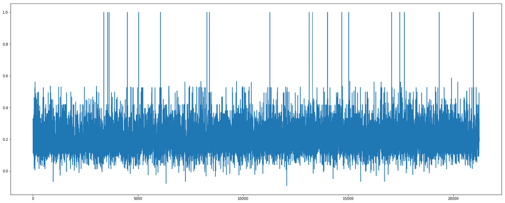

```python
def agg_sentence_max(sentence):

    if len(sentence) == 0:
        return ("",float("NaN"))
    else:
        text=" ".join([tupel[0] for tupel in sentence])
        max_value=max([tupel[1] for tupel in sentence])
        return (text,max_value)

score(l2,agg_sentence_max)
```

Ich glaube, das war nicht sinnvoll. Im Mittelfeld hat sich gefühlt nichts bewegt und es werden jetzt einfach die Sätze mit "Evil" angezeigt...

Ich schau mal, was passiert, wenn ich "evil" einfach rausnehme.

|  | text | value |
| --- | --- | --- |
| 4496 | iii the belief in supernatural source is not necessary men alone are quite capable every wickedness | 0.633545 |
| 19922 | you always did have the luck demon | 0.584519 |
| 15081 | the role would be keep close me keep silent but sinister support follow my lead where necessary most all watch my back yours | 0.565137 |
| 7993 | strange sinister selection people three score or more all races sizes shapes knelt before his retinue in wide arc | 0.565137 |
| 9689 | but torches are that bit more sinister | 0.565137 |
| 16571 | but her face soon smoothed out she smiled some more like murderous rage was her quality in man | 0.561175 |
| 20216 | in case any trace life remained in either the two murderous old mercenaries the lightest prick with this shining splinter metal coated with his own preparation number twelve would extinguish it for go… | 0.561175 |
| 16231 | there were no lines at all down in the ford just horsemen soldiers all tangled up into hundred murderous mindless little fights | 0.561175 |
| 17490 | sets musicians had formed at street corners would strike up martial tunes as she came close brassy blaring clanging away behind her merging with the off key offering the next impromptu band form mindl… | 0.561175 |
| 7234 | genuine murderous rage | 0.561175 |
| 101 | but i have tried so hard be popular they trotted between two dour faced soldiers spears steel caps polished murderous glint | 0.561175 |
| 10397 | stained door in stained wall pasted with fluttering old bills decrying the league eight as villains usurpers common criminals | 0.559843 |
| 830 | statues stood on either side staring off above the water monsters white stone streaky with bird droppings | 0.535615 |
| 7461 | was rolling on the ground still burning making thin screech like boiling kettle the flames casting crazy glare across the bobbing masks guests monsters faces everywhere shivers looked | 0.535615 |
| 3024 | he squeezed his eyes shut shook his head but when he opened them the monsters were still there heads bobbing over the milling crowd not even remarked upon | 0.535615 |
| 6471 | monsters giants | 0.535615 |
| 17472 | that was the difference between hero villain soldier murderer victory crime | 0.534527 |
| 9980 | yesterday hero tomorrow villain | 0.534527 |
| 14732 | one man villain is another hero after all | 0.534527 |
| 1223 | you have devil in you | 0.530363 |

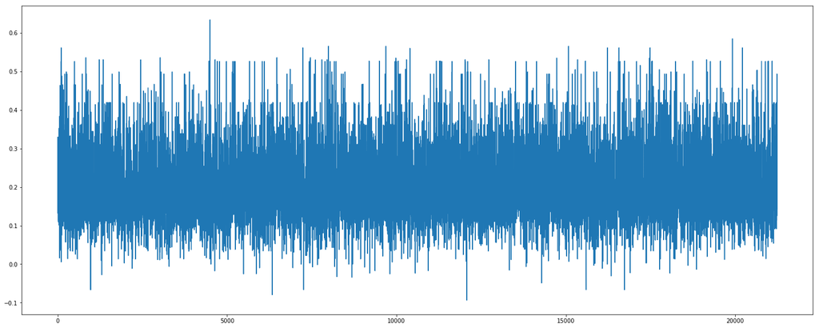

```python
l3=[[word for word in sentence if word[0]  != "evil"] for sentence in l2]

score(l3,agg_sentence_max)
```

Ja, damit hätte man rechnen müssen. Es werden jetzt bestimmte Worte gefunden (supernatural, sinister, murderous) und diese Sätze kommen dann noch oben.

Spontan fallen mir noch 2 weitere Aggregationen ein:

- berechne den Durchschnitt der Top k, sagen wir 3 Wörter
- berechne eine gewichtete Summe: Max+1/2 * Second+1/3 * Third usw. usf., dann noch bezüglich der Länge normalisieren

```python
#Das Austesten mehrere k ist bequemer mit Currying: Abhänging von k gebe ich hier eine unterschiedliche Funktion zurück
def agg_sentence_k_highest(k):
    def agg_sentence(sentence):
        if len(sentence) == 0:
            return ("",float("NaN"))
        else:
            text=" ".join([tupel[0] for tupel in sentence])
            top_k=sorted([tupel[1] for tupel in sentence])[-k:]
            top_k_mean=sum(top_k)/len(top_k)
            return (text,top_k_mean)
    return agg_sentence
```

|  | text | value |
| --- | --- | --- |
| 5161 | god | 0.498507 |
| 5151 | god | 0.498507 |
| 11634 | v for mercenaries are disunited thirsty for power undisciplined disloyal they are brave among their friends cowards before the enemy they have no fear god they do not keep faith with their fellow men … | 0.495037 |
| 4496 | iii the belief in supernatural source is not necessary men alone are quite capable every wickedness | 0.464654 |
| 6039 | when god means punish man the scriptures say he sends him stupid friends clever enemies | 0.464069 |
| 4714 | you must have some cowardly bloody enemies | 0.419196 |
| 2249 | bastard | 0.419181 |
| 2250 | bastard | 0.419181 |
| 12102 | allies are our enemies so his enemies are our allies | 0.416918 |
| 7184 | vengeance | 0.415824 |
| 7181 | vengeance | 0.415824 |
| 8053 | vengeance | 0.415824 |
| 10397 | stained door in stained wall pasted with fluttering old bills decrying the league eight as villains usurpers common criminals | 0.412111 |
| 8438 | someone with an appetite for truth had managed climb up there daub over them in streaky red greed torture cowardice | 0.410023 |
| 1807 | god god why could you not have sent me an honest life lead | 0.404520 |
| 19180 | these are ruthless times we live in in ruthless times mercy cowardice are entire opposites | 0.403560 |
| 17365 | for such clever bastard you are stupid bastard | 0.402087 |
| 73 | coward | 0.400973 |
| 11180 | that left two young staff officers bright swords drawn bright eyes full righteous hate | 0.394615 |
| 16603 | mad dogs savage their owner more often than their owner enemies | 0.391753 |

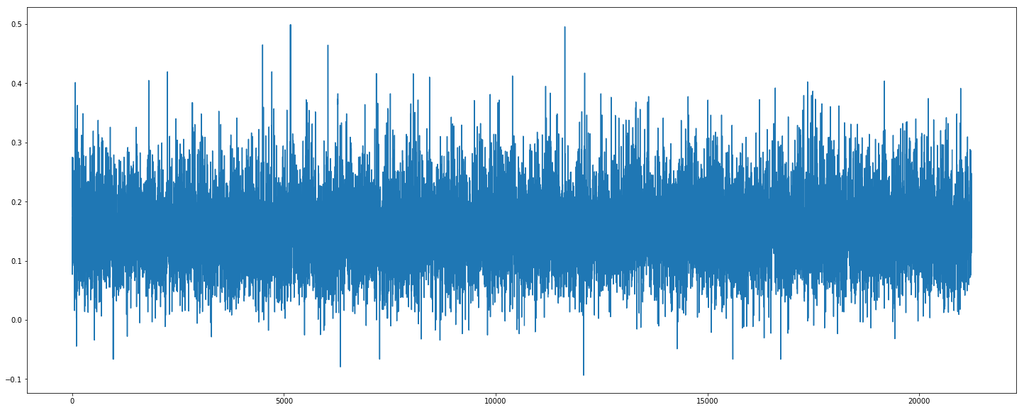

```python
score(l3,agg_sentence_k_highest(3))
```

Hier sieht man jetzt wieder, dass ich in dem Moment, wo ich den Durchschnitt betrachte, solche 1-Wort-Sätze ganz stark dabei sind. Ich probiere es nochmal mit k=5, aber perspektivisch wird das eher noch schlimmer sein.

Aber mir gefällt schon, was ich an den Sätzen sehe. Die Entwicklung hingegen ist immer noch ... nicht sichtbar.

|  | text | value |
| --- | --- | --- |
| 5161 | god | 0.498507 |
| 5151 | god | 0.498507 |
| 11634 | v for mercenaries are disunited thirsty for power undisciplined disloyal they are brave among their friends cowards before the enemy they have no fear god they do not keep faith with their fellow men … | 0.442075 |
| 2250 | bastard | 0.419181 |
| 2249 | bastard | 0.419181 |
| 7181 | vengeance | 0.415824 |
| 7184 | vengeance | 0.415824 |
| 8053 | vengeance | 0.415824 |
| 73 | coward | 0.400973 |
| 6039 | when god means punish man the scriptures say he sends him stupid friends clever enemies | 0.387876 |
| 6273 | bastards | 0.382103 |
| 7512 | bastards | 0.382103 |
| 17276 | innocent | 0.379174 |
| 13611 | traitor | 0.377377 |
| 6271 | murderers | 0.373046 |
| 13590 | stupid | 0.367899 |
| 5546 | poisoners | 0.367149 |
| 2835 | sorcery | 0.366828 |
| 2840 | sorcery | 0.366828 |
| 17704 | assassins | 0.364987 |

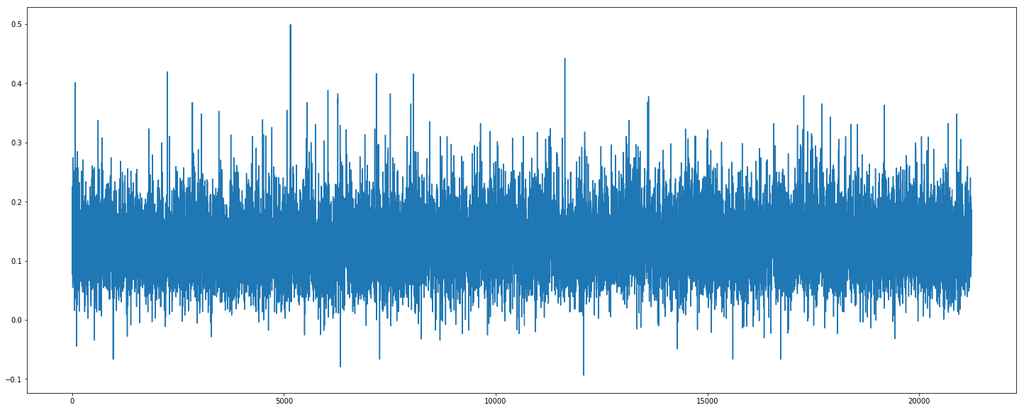

```python
score(l3,agg_sentence_k_highest(5))
```

Jup, noch schlimmer.

Der nächste Ansatz war über eine gewichtete Summe: Ich sortiere nach der Ähnlichkeit, dann bekommt das erste Wort Faktor 1, das 2. Wort Faktor 1/2, das i. Wort Faktor 2^(-i+1). Die maximale Summe der Faktoren für n Wörter ist dann 2-2^(-n+1), sodass ich um diesen Wert normalisieren muss.

```python
def agg_sentence_weighted_sum(sentence):
    if len(sentence) == 0:
        return ("",float("NaN"))
    else:
        text=" ".join([tupel[0] for tupel in sentence])

        #man beachte, dass hier jetzt 2^-i, weil das 1. Wort im Satz das Wort 0 in der Liste ist
        values_sorted=sorted([tupel[1] for tupel in sentence],reverse=True)
        weighted_values=[2**(-i)*value for (i,value) in enumerate(values_sorted)]
        normalization_factor=2-2**(-len(weighted_values)+1)

        top_k_mean=sum(weighted_values)/normalization_factor
        return (text,top_k_mean)
```

|  | text | value |
| --- | --- | --- |
| 5151 | god | 0.498507 |
| 5161 | god | 0.498507 |
| 4496 | iii the belief in supernatural source is not necessary men alone are quite capable every wickedness | 0.492151 |
| 11634 | v for mercenaries are disunited thirsty for power undisciplined disloyal they are brave among their friends cowards before the enemy they have no fear god they do not keep faith with their fellow men … | 0.478496 |
| 6039 | when god means punish man the scriptures say he sends him stupid friends clever enemies | 0.465716 |
| 12102 | allies are our enemies so his enemies are our allies | 0.440199 |
| 4714 | you must have some cowardly bloody enemies | 0.433660 |
| 10397 | stained door in stained wall pasted with fluttering old bills decrying the league eight as villains usurpers common criminals | 0.429596 |
| 1807 | god god why could you not have sent me an honest life lead | 0.424278 |
| 2249 | bastard | 0.419181 |
| 2250 | bastard | 0.419181 |
| 17490 | sets musicians had formed at street corners would strike up martial tunes as she came close brassy blaring clanging away behind her merging with the off key offering the next impromptu band form mindl… | 0.418037 |
| 7181 | vengeance | 0.415824 |
| 7184 | vengeance | 0.415824 |
| 8053 | vengeance | 0.415824 |
| 16231 | there were no lines at all down in the ford just horsemen soldiers all tangled up into hundred murderous mindless little fights | 0.415048 |
| 20216 | in case any trace life remained in either the two murderous old mercenaries the lightest prick with this shining splinter metal coated with his own preparation number twelve would extinguish it for go… | 0.414847 |
| 11180 | that left two young staff officers bright swords drawn bright eyes full righteous hate | 0.411340 |
| 12726 | he could not escape the irrational conclusion that this devil somehow knew his private thoughts | 0.408571 |
| 17550 | had once told her that the way turn lie into the truth was shout it often enough here was her self righteous face repeated over over plastered torn dog eared across the salt stained walls | 0.408333 |

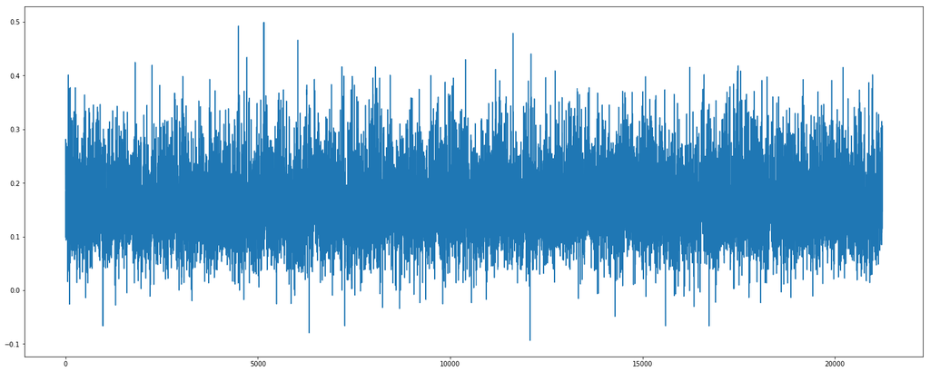

```python
score(l3,agg_sentence_weighted_sum)
```

Es gefällt mir schon nicht schlecht. Mal sehen, was passiert, wenn ich einfach nur Sätze mit mindestens 3 Worten betrachte

|  | text | value |
| --- | --- | --- |
| 3926 | iii the belief in supernatural source is not necessary men alone are quite capable every wickedness | 0.492151 |
| 10105 | v for mercenaries are disunited thirsty for power undisciplined disloyal they are brave among their friends cowards before the enemy they have no fear god they do not keep faith with their fellow men … | 0.478496 |
| 5220 | when god means punish man the scriptures say he sends him stupid friends clever enemies | 0.465716 |
| 10523 | allies are our enemies so his enemies are our allies | 0.440199 |
| 4102 | you must have some cowardly bloody enemies | 0.433660 |
| 9024 | stained door in stained wall pasted with fluttering old bills decrying the league eight as villains usurpers common criminals | 0.429596 |
| 1615 | god god why could you not have sent me an honest life lead | 0.424278 |
| 15259 | sets musicians had formed at street corners would strike up martial tunes as she came close brassy blaring clanging away behind her merging with the off key offering the next impromptu band form mindl… | 0.418037 |
| 14153 | there were no lines at all down in the ford just horsemen soldiers all tangled up into hundred murderous mindless little fights | 0.415048 |
| 17680 | in case any trace life remained in either the two murderous old mercenaries the lightest prick with this shining splinter metal coated with his own preparation number twelve would extinguish it for go… | 0.414847 |
| 9713 | that left two young staff officers bright swords drawn bright eyes full righteous hate | 0.411340 |
| 11087 | he could not escape the irrational conclusion that this devil somehow knew his private thoughts | 0.408571 |
| 15314 | had once told her that the way turn lie into the truth was shout it often enough here was her self righteous face repeated over over plastered torn dog eared across the salt stained walls | 0.408333 |
| 15241 | that was the difference between hero villain soldier murderer victory crime | 0.408192 |
| 14487 | mad dogs savage their owner more often than their owner enemies | 0.401507 |
| 18356 | will righteous leaders rise from the madness light the way brighter fairer beacon for all the world | 0.401344 |
| 7291 | someone with an appetite for truth had managed climb up there daub over them in streaky red greed torture cowardice | 0.400399 |
| 8241 | the stench self righteous hypocrisy in that place causes my bile rise | 0.399931 |
| 6274 | genuine murderous rage | 0.398927 |
| 6449 | they suddenly parted the incredible came thrashing straight at shivers white fire wreathing him like some devil burst out hell | 0.398161 |

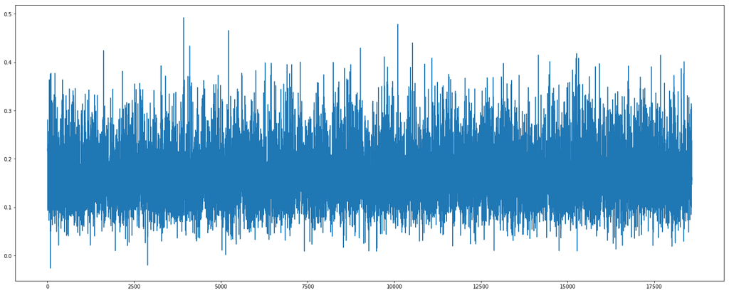

```python
l4=[sentence for sentence in l3 if len(sentence)>=3]
score(l4,agg_sentence_weighted_sum)
```

Um eine Entwicklung zu beobachten hilft das nicht so gut, aber mir gefällt die Auswahl der Sätze **sehr**. Ich gieße das ganze mal in eine Methode und spiele damit etwas rum.

```python
def get_sentences(text, word_to_compare, number_words_output):

    list_sentences=list()
    list_words_not_found=list()
    print(f"Berechne Similarites",end="\r")
    for i,sentence in enumerate(text):

        result_sentence=list()
        for word in sentence:
            try:
                if word != word_to_compare :
                    sim=model.similarity(word,word_to_compare)
                    result_sentence.append((word,sim))
            except:
               list_words_not_found.append(word)
        list_sentences.append(result_sentence)

    list_sentences=[sentence for sentence in list_sentences if len(sentence)>=3]

    def agg_sentence_weighted_sum(sentence):
        if len(sentence) == 0:
            return ("",float("NaN"))
        else:
            text=" ".join([tupel[0] for tupel in sentence])

            #man beachte, dass hier jetzt 2^-i, weil das 1. Wort im Satz das Wort 0 in der Liste ist
            values_sorted=sorted([tupel[1] for tupel in sentence],reverse=True)
            weighted_values=[2**(-i)*value for (i,value) in enumerate(values_sorted)]
            normalization_factor=2-2**(-len(weighted_values)+1)

            top_k_mean=sum(weighted_values)/normalization_factor
            return (text,top_k_mean)


    list_scored_sentences=[agg_sentence_weighted_sum(sentence) for sentence in list_sentences]

    display(pd.DataFrame(list_scored_sentences,columns=["text","value"]) \
        .sort_values(by=["value"], ascending=False)  \
        [:number_words_output]
    )
```

```python
get_sentences(text6,"love",10)
```

```
Berechne Similarites
```

|  | text | value |
| --- | --- | --- |
| 9714 | probably their mothers loved them probably they loved their mothers back | 0.576600 |
| 13549 | he did not know if he loved her or wanted her or just hated that she did not want him | 0.563482 |
| 5479 | particularly on behalf woman who already betrayed me once like homing pigeon drawn endlessly back its loved hated cage his mind was dragged back through nine wasted years | 0.554259 |
| 16724 | you cannot hesitate no matter the costs no matter do you know why i always loved you | 0.546015 |
| 1626 | how you always loved test us all | 0.519699 |
| 16194 | good thing i always loved gamble he carefully began unscrew the broken cage around the lamp | 0.518711 |
| 9640 | you are full passion but passion without discipline is no more than child tantrum | 0.514169 |
| 12527 | i understood that you always hated my father with passion | 0.511963 |
| 2625 | shivers was happy enough let him since the prick loved the sound his own voice so much | 0.509197 |
| 8826 | i thought he loved you like daughter | 0.506074 |

```python
get_sentences(text6,"city",10)
```

```
Berechne Similarites
```

|  | text | value |
| --- | --- | --- |
| 7127 | make for town on the chance they will find room for you risk being robbed by your protectors or caught up in the sack if the place falls | 0.433207 |
| 1478 | with that much he could hop the next boat back kick skinny from one end the town the other | 0.431746 |
| 11712 | he would been there at after the siege after they sacked the town | 0.430686 |
| 15177 | keep the out town | 0.429818 |
| 8255 | way in because the noble leaders cities are trusting folk always willing welcome uninvited guests into their places residence moved his eyeglass carefully across the front the sprawling building risin… | 0.421850 |
| 13120 | tall buildings old pale stone crowded tight behind them narrow windowed striped with black marble pressed in alongside steeply climbing streets crooked alleys thousand steps deep dark as the canyons m… | 0.415040 |
| 15174 | i love you but keep the out town | 0.414698 |
| 3311 | other side town that | 0.413747 |
| 16513 | no longer will the great cities our proud land struggle one against the other | 0.407599 |
| 7477 | southwards the blue sea the smoke industry still rising from the famous glass working district on its island just offshore the gliding specks seabirds circling above it | 0.403757 |

Bei "Love" sieht man schon Probleme, dass Wort-Varianten wie "loved" nach oben gepusht werden. Bei "City" dominiert das Quasi-Synonym "Town", aber Satz 7 und 10 gefallen mir sehr!

Das mit Wort-Varianten kann man mit Stemming beheben: Es wird nicht nur das Wort selber aus der Bewertung ausgeschlossen , sondern auch alle Wörter mit dem gleichen stem/Wortstamm. Dadurch wird z.B. für *hope* auch *hoped*,*hopes* und *hoping* ausgeschlossen.

Für das mit Synonymen *kann* man überlegen, ob man eventuell vorher einen Thesaurus drüber laufen lässt und alle Synonyme des Wortes auf das Wort mappt - oder der Methode eine Blackliste übergeben kann, wo ich z.B. hier "cities" und "town" mitgeben würde. Eine andere Möglichkeit wäre, Wörter aus der Bewertung zu nehmen, die *zu* nah sind bzw. eine zu große Similarity haben.

Insgesamt wäre es auch schöner, wenn man nicht den gefilterten Text angezeigt bekommt, sondern den "rohen" Text.

Ich fange mal mit dem Stemming an: Schließe nicht nur das Wort aus, sondern auch alle Wörter mit gleichem Stem.

```python
from stemming.porter2 import stem

def get_sentences2(text, word_to_compare, number_words_output,max_similarity=0.8):

    list_sentences=list()
    list_words_not_found=list()
    print(f"Berechne Similarites",end="\r")
    for i,sentence in enumerate(text):

        result_sentence=list()
        for word in sentence:
            try:
                if stem(word) != stem(word_to_compare) :
                    sim=model.similarity(word,word_to_compare)
                    result_sentence.append((word,sim))
            except:
               list_words_not_found.append(word)
        list_sentences.append(result_sentence)

    list_sentences=[sentence for sentence in list_sentences if len(sentence)>=3]

    def agg_sentence_weighted_sum(sentence):
        if len(sentence) == 0:
            return ("",float("NaN"))
        else:
            text=" ".join([tupel[0] for tupel in sentence])

            #man beachte, dass hier jetzt 2^-i, weil das 1. Wort im Satz das Wort 0 in der Liste ist
            values_sorted=sorted([tupel[1] for tupel in sentence if tupel[1]<max_similarity],reverse=True)
            weighted_values=[2**(-i)*value for (i,value) in enumerate(values_sorted)]
            normalization_factor=2-2**(-len(weighted_values)+1)

            top_k_mean=sum(weighted_values)/normalization_factor
            return (text,top_k_mean)


    list_scored_sentences=[agg_sentence_weighted_sum(sentence) for sentence in list_sentences]

    display(pd.DataFrame(list_scored_sentences,columns=["text","value"]) \
        .sort_values(by=["value"], ascending=False)  \
        [:number_words_output]
    )
```

```python
get_sentences2(text6,"hope",10,0.55)
```

```
Berechne Similarites
```

|  | text | value |
| --- | --- | --- |
| 5508 | the fact is i need the chance i need change much more importantly i desperately need the money | 0.476884 |
| 18511 | glad for the chance look her in the eye one more time even if they had the jailer half dozen guards for company | 0.466805 |
| 8384 | they are going try get us talk when we do not have anything say they want hear they are going fucking kill us | 0.458525 |
| 3089 | if you are good man you try think about what the right thing is every day your life you build things be proud so bastards can come burn them in moment you make sure say thank you kindly each time they… | 0.457523 |
| 10264 | well you would know the odds better than me i am sure but happy chance indeed on that we can agree | 0.454715 |
| 2649 | do you want do i look like i want with half get through my bloody gate | 0.452400 |
| 4318 | when it comes arranging the entertainments i want you hire who we say when we say how we say | 0.451454 |
| 10293 | do not say lost until i have had chance view the damage | 0.448105 |
| 9278 | i just wanted say while there chance | 0.441755 |
| 13088 | but when i heard the bloody nine nailed my bastard brother head up i did not know whether i hated the man for doing it or hated that he would robbed me o the chance or wanted kiss him for the like you… | 0.440661 |

```python
get_sentences2(text6,"love",10,0.55)
```

```
Berechne Similarites
```

|  | text | value |
| --- | --- | --- |
| 13085 | but when i heard the bloody nine nailed my bastard brother head up i did not know whether i hated the man for doing it or hated that he would robbed me o the chance or wanted kiss him for the like you… | 0.458587 |
| 2789 | noise work play men beasts calls folk selling buying wheels rattling hammers clanging splinters song scraps music joy despair all mixed up together like stew in great pot | 0.450703 |
| 6841 | liked surround himself with the curious that he might seem strange romantic | 0.441509 |
| 7999 | maybe beneath this harsh yet beautiful shell i am really still soft hearted farmer daughter only wanting do good | 0.439234 |
| 4516 | instead what welled up in him was mixture worn out self pity sappy joy most all piercing shame at seeing in her face how far he had fallen | 0.438576 |
| 6874 | she hated do it hated watch her do it but had given them home they owed him so she did it still | 0.437867 |
| 13548 | he did not know if he her or wanted her or just hated that she did not want him | 0.436184 |
| 10416 | the noble duke owner this wonderful bath was as staunch warlike an ally as could be imagined when duke power was long leagues away on the other side the great walls | 0.434840 |
| 16511 | but will stand as brothers eternal bound willingly by happy ties friendship culture common heritage | 0.433596 |
| 10814 | he always carried special mix four spice with him crushed his taste the oil native the region around had wonderful nutty | 0.432045 |

Ok, manchmal funktioniert es also ganz gut, manchmal nicht so gut.

Kann man wenigstens die *Action*-Szenen aus dem Text finden? Als Ansatz denke ich mir folgendes: Für jeden Satz betrachte das Werb und score es bezüglich seiner Ähnlichkeit zu *fight*. Dann betrachte einen Moving Average über die Sätze.

In Kampfszenen kommen ja häufig Wörter wie "stab", "slash", "parry", "punch" etc. vor; praktisch jeder Satz wird so etwas enthalten. In der normalen Handlung hingegen kommen solche Wörter nur vereinzelt vor.

Der Moving Average würde also Spitzen um die Kampfszenen haben, in der normalen Handlung aber würden die Sätze mit diesen Verben wegen der Durchschnittsbildung "untergehen".

```python
import nltk


tagged=[nltk.pos_tag(sentence) for sentence in text6]

#Raus kommt für jedes Wort das Tupel (Wort,Kenner). Kenner, die ein "V" enthalten, sind Verben
verbs=[[word for word in sentence if "V" in word[1]] for sentence in tagged]
```

```python
verbs[:20]
```

```
[[('was', 'VBD')],
 [('leaked', 'VBD'),
  ('stained', 'VBD'),
  ('red', 'VBD'),
  ('marked', 'VBD'),
  ('stolen', 'VBN')],
 [('twisted', 'VBD'), ('ash', 'VBP')],
 [('was', 'VBD')],
 [],
 [('look', 'VBP')],
 [('sighed', 'VBD'), ('was', 'VBD')],
 [('had', 'VBD'), ('spent', 'VBN'), ('preening', 'VBG')],
 [('are', 'VBP')],
 [('stating', 'VBG'), ('is', 'VBZ')],
 [('prove', 'VB'), ('are', 'VBP')],
 [('yawned', 'VBD'), ('stretched', 'VBN'), ('made', 'VBD'), ('wait', 'VB')],
 [('hear', 'VB')],
 [('cleared', 'VBD'), ('held', 'VBD'), ('preparing', 'VBG')],
 [('is', 'VBZ'), ('shimmering', 'VBG')],
 [],
 [('was', 'VBD')],
 [],
 [('liked', 'VBD'), ('had', 'VBD')],
 []]
```

Was sind denn die Sätze, wo er nichts gefunden hat?

```python
text6[15:20]
```

```
[['you', 'pompous', 'cock'],
 ['what', 'was', 'it', 'yesterday'],
 ['a', 'curtain', 'of', 'midnight'],
 ['i', 'liked', 'that', 'better', 'it', 'had', 'some', 'poetry', 'to', 'it'],
 ['bad', 'poetry', 'but', 'still']]
```

Sätze ohne Verben halt...

```python
def get_similarities(list_of_sentences_input, word_to_compare_to):

    list_scored=list()
    list_words_not_found=list()
    for i,sentence in enumerate(list_of_sentences_input):

        result_sentence=list()
        for word in sentence:
            word=word[0]
            try:
                if stem(word) != stem(word_to_compare_to) :
                    sim=model.similarity(word,word_to_compare_to)
                    result_sentence.append((word,sim))
            except:
               list_words_not_found.append(word)
        list_scored.append(result_sentence)
    return list_scored

list_scored=get_similarities(verbs,"fight")
```

Ich probiere es erstmal mit einer von Sätzen unabhängigen, sprich flatten Liste. Für eine erste Stichprobe schaue ich mir auch erstmal das ganze ohne Moving Average an.

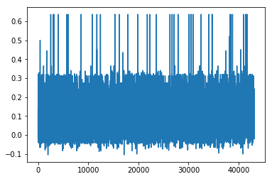

```python
scored_flat=[round(value[1],3) for sentence in list_scored for value in sentence ]
plt.plot(scored_flat)
```

Das Erste was mir auffällt: Es gibt praktisch keine Wörter, die wirklich entgegengesetzt im Vektorraum sind (Cosinus-Similarity von -1). Ich bin mir aber auch unsicher, wie man das zu interpretieren hat.

Aber gefühlt häuft es sich ja an einigen Stellen, an anderen Stellen nicht, wie ich mir gedacht habe.

```python
import math

def moving_average(list_input, window_size):
    first_position=0
    last_position=len(list_input)-window_size
    list_of_averages=list()
    for position in range(first_position,last_position+1):
        sub_list=[value for value in list_input[position:position+window_size] if not math.isnan(value)]
        list_of_averages.append(sum(sub_list)/len(sub_list))
    return list_of_averages
```

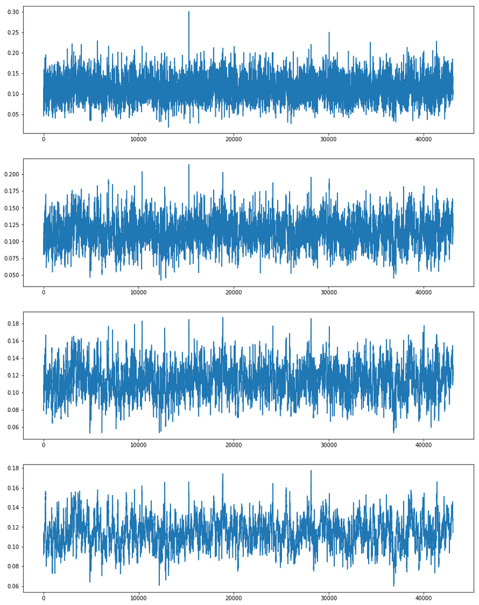

```python
def plot(values):

    fig = plt.figure(figsize=(15,20))

    window_sizes=[10,20,30,50]
    for i,window_size in enumerate(window_sizes):

        ax = fig.add_subplot(len(window_sizes),1,i+1)
        ax.plot(moving_average(values,window_size))
plot(scored_flat)
```

Man sieht ein paar wenige Spitzen, aber ich weiß, dass es mehr solche Szenen im Buch gab.

Ein Problem könnte das folgende sein: Im just von mir verfassten Satz "He had to parry, so he did it" kommen 3 Verben vor, sodass das Hauptverb stark abgeschwächt wird.

Was helfen könnte, wäre, das Maximum pro Satz zu nehmen. Dazu benutze ich einen kleinen Trick, um auch leere Sätze mit verarbeiten zu können, damit mir die x-Achse nicht verzerrt wird. (Ansonsten müsste ich diese Sätze rausnehmen und wenn ein Satz im Diagramm mit 1000 angezeigt wird, ist es in Wirklichkeit z.B. Satz 1050)

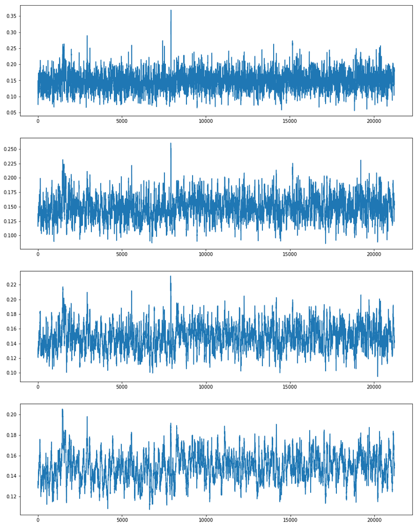

```python
dummy=("",float("NaN"))
max_values=[max([word[1] for word in sentence+[dummy]]) for sentence in list_scored ]
plot(max_values)
```

Sieht direkt etwas besser aus. Sicherheitshalber schaue ich mal nicht nur nach "fight", sondern auch nach "action".

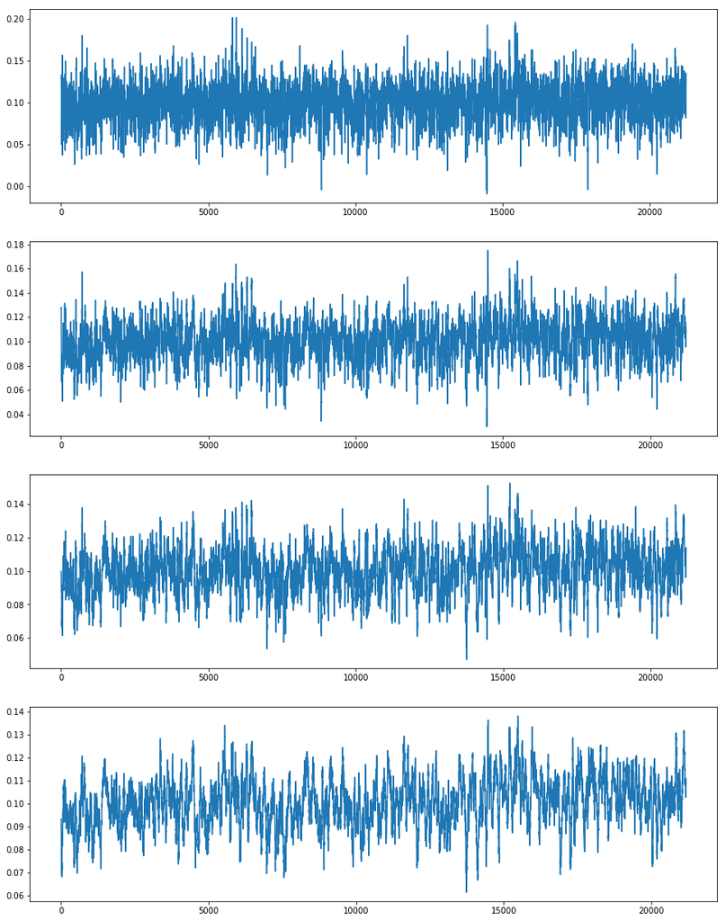

```python
list_scored=get_similarities(verbs,"action")
max_values=[max([word[1] for word in sentence+[dummy]]) for sentence in list_scored ]

plot(max_values)
```

Hmm, schon doch anders.

Wirklich interessant wäre ja, zu wissen, was diese Sätze sind.

```python
df1=pd.DataFrame(max_values,columns=["max_value"])
df2=pd.DataFrame(text5,columns=["sentence"])
```

```python
df1
```

|  | max_value |
| --- | --- |
| 0 | 0.113456 |
| 1 | 0.125225 |
| 2 | 0.120619 |
| 3 | 0.113456 |
| 4 | NaN |
| 5 | 0.215481 |
| 6 | 0.113456 |
| 7 | 0.126627 |
| 8 | 0.102978 |
| 9 | 0.127559 |
| 10 | 0.110061 |
| 11 | 0.162989 |
| 12 | 0.108933 |
| 13 | 0.125362 |
| 14 | 0.127559 |
| 15 | NaN |
| 16 | 0.113456 |
| 17 | NaN |
| 18 | 0.126627 |
| 19 | NaN |
| 20 | NaN |
| 21 | -0.005849 |
| 22 | 0.053200 |
| 23 | 0.126407 |
| 24 | 0.013036 |
| 25 | 0.116626 |
| 26 | 0.104339 |
| 27 | 0.117456 |
| 28 | -0.024011 |
| 29 | -0.040020 |
| ... | ... |
| 21210 | 0.209174 |
| 21211 | NaN |
| 21212 | 0.083091 |
| 21213 | 0.127559 |
| 21214 | 0.069087 |
| 21215 | 0.127559 |
| 21216 | 0.135153 |
| 21217 | 0.166173 |
| 21218 | 0.079653 |
| 21219 | 0.113456 |
| 21220 | 0.048143 |
| 21221 | NaN |
| 21222 | 0.011522 |
| 21223 | -0.015358 |
| 21224 | 0.117456 |
| 21225 | 0.126627 |
| 21226 | 0.127678 |
| 21227 | 0.180601 |
| 21228 | 0.110874 |
| 21229 | 0.137139 |
| 21230 | 0.137139 |
| 21231 | 0.143628 |
| 21232 | NaN |
| 21233 | 0.137139 |
| 21234 | 0.113456 |
| 21235 | 0.125910 |
| 21236 | 0.104339 |
| 21237 | 0.124552 |
| 21238 | 0.113456 |
| 21239 | NaN |

21240 rows × 1 columns

```python
df2
```

|  | sentence |
| --- | --- |
| 0 | the sunrise was the colour of bad blood |
| 1 | it leaked out of the east and stained the dark sky red marked the scraps of cloud with stolen gold |
| 2 | underneath it the road twisted up the mountainside towards the fortress of fontezarmo—a cluster of sharp towers ash black against the wounded heavens |
| 3 | the sunrise was red black and gold |
| 4 | the colours of their profession |
| 5 | you look especially beautiful this morning monza |
| 6 | she sighed as if that was an accident |
| 7 | as if she had not spent an hour preening herself before the mirror |
| 8 | facts are facts |
| 9 | stating them is not a gift |
| 10 | you only prove you are not blind |
| 11 | she yawned stretched in her saddle made him wait a moment longer |
| 12 | but i will hear more |
| 13 | he noisily cleared his throat and held up one hand a bad actor preparing for his grand speech |
| 14 | your hair is like to a veil of shimmering sable |
| 15 | you pompous cock |
| 16 | what was it yesterday |
| 17 | a curtain of midnight |
| 18 | i liked that better it had some poetry to it |
| 19 | bad poetry but still |
| 20 | shit |
| 21 | he squinted up at the clouds |
| 22 | your eyes then gleam like piercing sapphires beyond price |
| 23 | i have got stones in my face now |
| 24 | lips like rose petals |
| 25 | she spat at him but he was ready and dodged it the phlegm clearing his horse and falling on the dry stones beside the track |
| 26 | that to make your roses grow arsehole |
| 27 | you can do better |
| 28 | harder every day he muttered |
| 29 | that jewel i bought looks wonderful well on you |
| ... | ... |
| 21210 | take it |
| 21211 | alright |
| 21212 | he bent down and dug it out of the muck wiped it on his shirt |
| 21213 | i is not proud |
| 21214 | monza turned and walked away towards the stairway towards the lamplight spilling from it |
| 21215 | so that how this ends is it |
| 21216 | he called after her |
| 21217 | that the ending |
| 21218 | you think you deserve something better |
| 21219 | and she was gone |
| 21220 | he slid the ring onto his little finger and watched it sparkle |
| 21221 | something worse |
| 21222 | move then bastard snarled one of the guards waving a drawn sword |
| 21223 | shivers grinned back |
| 21224 | oh i am gone do not you worry on that score |
| 21225 | i have had my fill of styria |
| 21226 | he smiled as he stepped out of the darkness of the tunnel and onto the bridge that led away from fontezarmo |
| 21227 | he scratched at his itching face took in a long breath of cold free air |
| 21228 | all things considered and well against the run of luck he reckoned he would come out alright |
| 21229 | might be he would lost an eye down here in styria |
| 21230 | might be he was leaving no richer than when he would stepped off the boat |
| 21231 | but he was a better man of that he would no doubt |
| 21232 | a wiser man |
| 21233 | used to be he was his own worst enemy |
| 21234 | now he was everyone else |
| 21235 | he was looking forward to getting back to the north finding some work that suited him |
| 21236 | maybe he would make a stop in uffrith pay his old friend vossula a little visit |
| 21237 | he set off down the mountain away from the fortress boots crunching in the grey dust |
| 21238 | behind him the sunrise was the colour of bad blood |
| 21239 |  |

21240 rows × 1 columns

Die Indizes stimmen noch überein, sehr gut. Dann kann ich die nämlich einfach spaltenweise konkatenieren, wenn ich mich um das moving average gekümmert habe.

```python
vals_fight=[max([word[1] for word in sentence+[dummy]]) for sentence in get_similarities(verbs,"fight") ]
vals_action=[max([word[1] for word in sentence+[dummy]]) for sentence in get_similarities(verbs,"action") ]

moving_average_fight=moving_average(vals_fight,10)
moving_average_action=moving_average(vals_action,10)

df_fight=pd.DataFrame(moving_average_fight,columns=["moving_average_fight"])
df_action=pd.DataFrame(moving_average_action,columns=["moving_average_action"])
df_text=pd.DataFrame(text5,columns=["text"])

df=pd.concat([df_fight,df_action,df_text],axis=1)
df[:10]
```

|  | moving_average_fight | moving_average_action | text |
| --- | --- | --- | --- |
| 0 | 0.109669 | 0.128762 | the sunrise was the colour of bad blood |
| 1 | 0.126496 | 0.128385 | it leaked out of the east and stained the dark sky red marked the scraps of cloud with stolen gold |
| 2 | 0.135178 | 0.132581 | underneath it the road twisted up the mountainside towards the fortress of fontezarmo—a cluster of sharp towers ash black against the wounded heavens |
| 3 | 0.143091 | 0.131282 | the sunrise was red black and gold |
| 4 | 0.146689 | 0.132605 | the colours of their profession |
| 5 | 0.140438 | 0.132101 | you look especially beautiful this morning monza |
| 6 | 0.140619 | 0.122836 | she sighed as if that was an accident |
| 7 | 0.140619 | 0.122836 | as if she had not spent an hour preening herself before the mirror |
| 8 | 0.141939 | 0.122362 | facts are facts |
| 9 | 0.146656 | 0.125318 | stating them is not a gift |

Als erstes schaue ich mir mal Szenen mit großen Unterschied zwischen "Action" und "Fight" an.

```python
df2=df.copy()
df2["difference_value"]=(df2.moving_average_action-df2.moving_average_fight).abs()
df2.sort_values(by=["difference_value"],ascending=False)[:10]
```

|  | moving_average_fight | moving_average_action | text | difference_value |
| --- | --- | --- | --- | --- |
| 7921 | 0.368727 | 0.125210 | some fucking chance of that | 0.243516 |
| 7920 | 0.328787 | 0.106141 | ario one time mistress paused in the doorway | 0.222646 |
| 7922 | 0.341898 | 0.124661 | and she was gone | 0.217237 |
| 7917 | 0.333438 | 0.118320 | are not you going to wish me luck | 0.215118 |
| 7924 | 0.335453 | 0.122428 | henry v the thousand swords fought for ospria against muris | 0.213026 |
| 7923 | 0.339386 | 0.127505 | iv visserine war without fire is as worthless as sausages without mustard | 0.211880 |
| 7918 | 0.313209 | 0.109341 | what | 0.203867 |
| 15166 | 0.265494 | 0.064862 | let us say men anyway | 0.200633 |
| 2933 | 0.289317 | 0.090504 | but you fought in battles | 0.198813 |
| 2931 | 0.264621 | 0.066227 | you were a soldier then | 0.198394 |

Jetzt habe ich das Problem, dass durch den Moving Average-Ansatz ich für die gleiche Spitze mehrere Sätze sehe. Ich werde mir die Spitzen graphisch ausgeben lassen, dann manuell schauen, wo diese sind und dann pro "Bereich" mir die Stelle mit dem höchsten Wert ausgeben lassen.

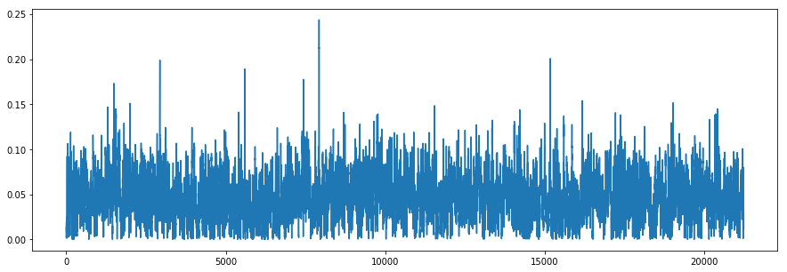

```python
fig = plt.figure(figsize=(15,5))
plt.plot(df2.difference_value)
```

```python
indices_start=[2500,5000,7000,15000]
indices=[]
for index_start in indices_start:
    query_filter="@index_start < index & index < @index_start + 1000 "
    indices.append(df2.query(query_filter).difference_value.idxmax())
indices
```

```
[2933, 5593, 7921, 15166]
```

```python
for index in indices:
    print((df2[index:index+1]))
    print(". ".join(text5[index:index+10]), end="\n\n\n")
```

```
      moving_average_fight  moving_average_action                        text  \
2933              0.289317               0.090504   but you fought in battles

      difference_value
2933          0.198813
 but you fought in battles.  and again.  shivers ploughed on as if he would said yes.  not much other choice now.  i fought in a few.  charged in the mist with bethod carls north of the cumnur.  held the line next to rudd threetrees at dunbrec.  fought seven days in the mountains with the dogman.  s…


      moving_average_fight  moving_average_action  \
5593              0.258355               0.069355

                                                                                                                          text  \
5593   we fought side by side as noble members of the thousand swords most famous mercenary brigade in the circle of the world

      difference_value
5593             0.189
 we fought side by side as noble members of the thousand swords most famous mercenary brigade in the circle of the world.  monza frowned sideways at him.  his old bloody stories were bringing back things done and choices made she would sooner have left in the past.  we fought across styria and back …


      moving_average_fight  moving_average_action  \
7921              0.368727                0.12521

                              text  difference_value
7921   some fucking chance of that          0.243516
 some fucking chance of that.  and she was gone.  iv visserine war without fire is as worthless as sausages without mustard.  henry v the thousand swords fought for ospria against muris.  they fought for muris against sipani.  they fought for sipani against muris then for ospria again.  between cont…


       moving_average_fight  moving_average_action                    text  \
15166              0.265494               0.064862   let us say men anyway

       difference_value
15166          0.200633
 let us say men anyway.  scattered laughter a whoop of approval.  my boys you all know my stamp.  some of you have fought beside me  or at any rate in front.  more laughter.  the rest of you know my  spotless reputation.  and more yet.  you all know that i above all am one of you.  a soldier yes.  a…
```

Das sind nun auch nicht wirklich Action-Szenen. Wie sieht es in die andere Richtung aus - wo die Similarity zu "Action" größer ist als zu "Fight"?

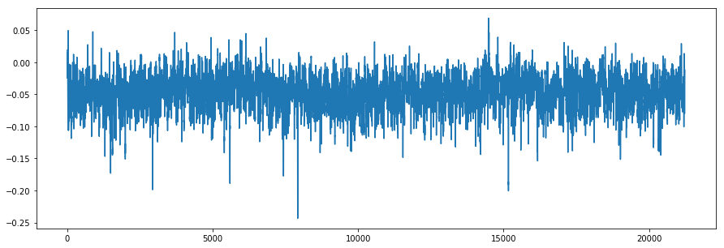

```python
df2=df.copy()
df2["difference_value"]=(df2.moving_average_action-df2.moving_average_fight)
df2.sort_values(by=["difference_value"],ascending=False)[:10]

fig = plt.figure(figsize=(15,5))
plt.plot(df2.difference_value)
```

Ok, in die andere Richtung passieren hohe Diskrepanzen auch einfach nicht. Was ist die eine Stelle um 14500 rum?

```python
indices_start=[14000]
indices=[]
for index_start in indices_start:
    query_filter="@index_start < index & index < @index_start + 1000 "
    indices.append(df2.query(query_filter).difference_value.idxmax())
indices

for index in indices:
    print((df2[index:index+1]))
    print(". ".join(text5[index:index+10]), end="\n\n\n")
```

```
       moving_average_fight  moving_average_action  \
14480              0.123525               0.192424

                                                                       text  \
14480   of course and the thousand swords will fight you may depend on that

       difference_value
14480          0.068899
 of course and the thousand swords will fight you may depend on that.  they will fight every man.  asserted andiche.  like devils.  added victus.  but it is how they are to be made to fight best that concerns me as their captain general.  they have lost two leaders in a brief space.  he hung his hea…
```

Aha, sehr interessant. Der Satz hat keinen so hohen "Fight"-Wert, da das Wort "Fight" ja immer herausgenommen wird - dementsprechend fehlt da einiges. Bei Action hingegen kommt es dazu, dass "Fight" und "Action" wahrscheinlich eine hohe Ähnlichkeit haben, daher bekommt diese Szene einen höheren "Action"-Wert.

Wie sehen denn nun solche "Fight"-Szenen aus?

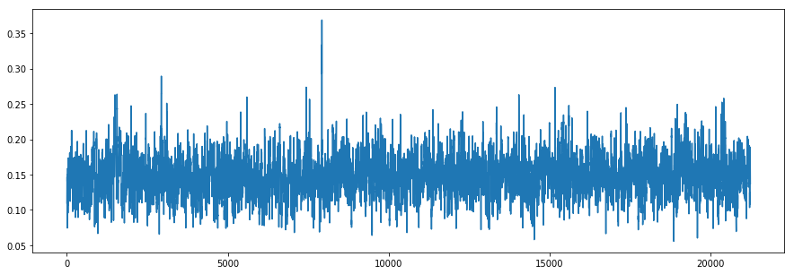

```python
fig = plt.figure(figsize=(15,5))
plt.plot(df.moving_average_fight)
```

```python
indices_start=[1000,2500,7000,20000]
indices=[]
for index_start in indices_start:
    query_filter="@index_start < index & index < @index_start + 1000 "
    indices.append(df.query(query_filter).moving_average_fight.idxmax())
indices

for index in indices:
    print((df[index:index+1]))
    print(". ".join(text5[index:index+10]), end="\n\n\n")
```

```
      moving_average_fight  moving_average_action     text
1556              0.263701               0.120633   my leg
 my leg.  rat face was yelling clutching at the back of his knee with one bloody hand.  my fucking leg.  stop whining or i will slit the other one.  baldy was lying there saying nothing.  red nose had finally fought his way moaning to his knees.  want my boots do you.  shivers took a step and kicked…


      moving_average_fight  moving_average_action                        text
2933              0.289317               0.090504   but you fought in battles
 but you fought in battles.  and again.  shivers ploughed on as if he would said yes.  not much other choice now.  i fought in a few.  charged in the mist with bethod carls north of the cumnur.  held the line next to rudd threetrees at dunbrec.  fought seven days in the mountains with the dogman.  s…


      moving_average_fight  moving_average_action  \
7921              0.368727                0.12521

                              text
7921   some fucking chance of that
 some fucking chance of that.  and she was gone.  iv visserine war without fire is as worthless as sausages without mustard.  henry v the thousand swords fought for ospria against muris.  they fought for muris against sipani.  they fought for sipani against muris then for ospria again.  between cont…


       moving_average_fight  moving_average_action  \
20405              0.257948               0.118252

                                                                                                                                              text
20405   shenkt turned his hand over and let the ring fall and it bounced once and tinkled down spinning on the floor beside her twisted right hand
 shenkt turned his hand over and let the ring fall and it bounced once and tinkled down spinning on the floor beside her twisted right hand.  she did not thank him but he had not expected thanks.  it was not for her thanks that he had done it.  kill them both.  screamed orso.  shenkt was always surp…
```

Hmm, damit bin ich noch unzufrieden.

Der methodisch korrekte Ansatz wäre natürlich, *vorher* die Szenen zu flaggen und nicht die Top N zeigen zu lassen und nach Bauchgefühl zu entscheiden. Für ein PoC soll das aber mal reichen.

Um zumindest etwas manuellen Aufwand herauszunehmen, werde ich diese Suche nach Spitzen automatisieren.

```python
def print_scenes(word_to_compare_to, number_of_scenes=5, size_slice=500):

    scored=[max([word[1] for word in sentence+[dummy]]) for sentence in get_similarities(verbs,word_to_compare_to) ]
    moving_average_scores=moving_average(scored,10)

    df_scores=pd.DataFrame(moving_average_scores,columns=["moving_average_scores"])
    df_text=pd.DataFrame(text5,columns=["text"])
    df=pd.concat([df_scores,df_text],axis=1)

    #für jedes Slice finde Index mit höchstem Score
    indices=[]
    for i in range(1,len(df),size_slice):
        df2=df[i:i+size_slice]
        indices.append(df2.moving_average_scores.idxmax())

    #Spiele Score an und sortiere, sodass die Top N genommen werden können
    values=[ (index,df.moving_average_scores[index]) for index in indices]
    values.sort(key=lambda pair:pair[1],reverse=True)

    #printe Szenen
    for pair in values[:number_of_scenes]:
        index=pair[0]
        print(". ".join(text5[index:index+10]), end="\n\n")
```

```python
print_scenes("sword")
```

```
 friendly jumped it cleaver coming down towards the northman head.  shivers jerked his shield up in time and the blade clanged from its dented boss sending a jolt up friendly arm right to his shoulder.  he stabbed at shivers side as he passed got his arm tangled with the haft of the axe as it swung …

 i will kill you.  but he did not come on.  when.  asked friendly blades hanging loose from his hands.  tomorrow.  i will— shivers stick cracked down on the back of gobba skull.  a good blow right on the best spot crumpling his knees easily as paper.  he flopped down slack cheek thumping against the…

 first thing she saw was another soldier open helmet with a bearded face inside stabbing with a spear.  she tried to twist away but it caught her hard in the chest point shrieked down her breastplate sent her toppling head snapping forwards.  she was on her back in the ford and the soldier stumbled …

 back.  cosca sidestepped a sword thrust whipped his cane around a long thin blade sliding free of it ran a man through the neck with a swift jab.  he slashed at someone else missed and almost stabbed shivers as he lurched past.  one of ario gentlemen mask like a squares board nearly caught cosca wi…

 colonel rigrat whipped his well lathered horse between the tents sending idle mercenaries scattering and reined the beast in savagely not far away.  he slid from the saddle nearly fell tore his boot from the stirrup and stormed up ripping off his gloves face flushed with sweaty fury.  cosca.  nicom…
```

```python
print_scenes("wound")
```

```
 there was a crash of tinkling glass and a flailing body came flying through one of the windows of the gambling hall.  panic and madness spread like fire in a dry field.  one of the jugglers was flinging knives flying metal clattering about the yard thudding into flesh and wood just as deadly to fri…

 he came at her in earnest pushing her from one side of the garden to the other parrying desperately jabbing weakly back when she could but not often and to no effect.  she would heard it said he was one of the greatest swordsmen in the world and it was not hard to believe even with his left hand.  …

 too cold too numb too broken.  there was a crack as the spear shaft splintered.  the waterwheel started turning slowly slowly metal squealing cogs grating and dragged faithful back under.  the stream kept on flowing.  his hand went limp and that was that.  five dead two left.  she let it go breathi…

 a little closer to the powder than was comfortable perhaps but cosca had always loved to gamble.  he had always loved triumphant rhetoric too but time was a factor.  so he turned for the shadowy passageway and hurried down it.  a dozen cramped strides and he was already breathing hard again.  a doz…

 friendly punched at his side struggling to get a good fist around that big circle of wood but shivers had more weight and all the momentum.  friendly was bundled through the door frame thudding against his shoulder shield digging into his chest gaining pace all the time.  his boots kicked at the fl…
```

Das sieht gut aus!

Ich denke, man kann also sagen: Grundsätzlich ist es möglich, mit diesem Ansatz Action-Szenen zu erkennen. Wie gut das funktioniert und wie verallgemeinerbar das ist, müsste man noch näher untersuche.